# Survival package

## Introductie

Over twee jaar wil ik me graag bezighouden met onderzoek over haematologie of oncologie, in combinatie met data science en zoölogie. Bij de minor Data Science leer ik verschillende vaardigheden en technieken, waardoor ik dit kan toepassen in mijn afstudeerstage en later in mijn werk. Ik zou graag willen werken bij een ziekenhuis of universiteit, met name onderzoek over ziektes en medicijnen. Voor mijn afstudeerstage zou ik graag onderzoek willen doen met proefdieren en medicijnen. Met Data Science kunnen we gegevens analyseren en inzichten uit halen, zoals verbeteren van diagnoses en ontdekken van nieuwe manieren om ziektes/ te bestrijden.

Een nieuwe skill die ik graag wil leren is het visualiseren van data. Door nieuwe visualisatietools te ontdekken en toe te passen, zou ik in staat zijn om een nieuw type grafiek te maken en het visualiseren van mijn gegevens te vergemakkelijken. Voor de vrije ruimte ga ik de ‘survival’ package van R leren. ‘Survival’ package wordt gebruikt voor het visualiseren van overleveingsanalyses. Met deze package kan je de tijd tot overlijden of optreden van ziektes bestuderen. Dit is handig voor mijn afstudeerstage en op de werkveld. Met behulp van deze skill kan ik met interesse van haematologie/oncologie de verkregen data beter analyseren en gemakkelijker visualiseren.

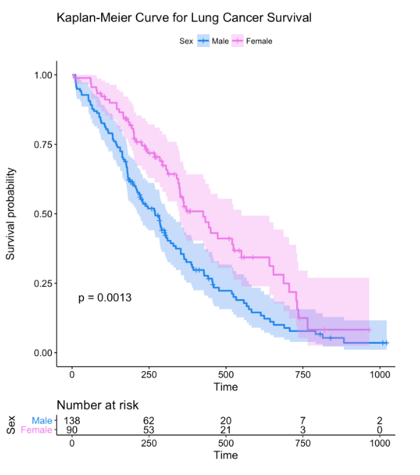

Kaplan-Meier plot. De Kaplan-Meier plot van de survival package toont aan de cumulatieve overlevingskansen tegenover tijd.

| Dag | Planning |
| --- | --- |
| Dag 1 | Inlezen van meerdere papers en websites met voorbeelden |
| Dag 2 | Bekijken van YouTube video’s en zoeken naar workflows |
| Dag 3 | Zoeken van nepdata en begin maken met een script |
| Dag 4 | Verder aan script werken |

## Data

| age | anaemia | creatinine_phosphokinase | diabetes | ejection_fraction | high_blood_pressure | platelets | serum_creatinine | serum_sodium | sex | smoking | time | DEATH_EVENT |
| --- | --- | --- | --- | --- | --- | --- | --- | --- | --- | --- | --- | --- |
| 75 | 0 | 582 | 0 | 20 | 1 | 265000 | 1.9 | 130 | 1 | 0 | 4 | 1 |
| 55 | 0 | 7861 | 0 | 38 | 0 | 263358.03 | 1.1 | 136 | 1 | 0 | 6 | 1 |
| 65 | 0 | 146 | 0 | 20 | 0 | 162000 | 1.3 | 129 | 1 | 1 | 7 | 1 |
| 50 | 1 | 111 | 0 | 20 | 0 | 210000 | 1.9 | 137 | 1 | 0 | 7 | 1 |
| 65 | 1 | 160 | 1 | 20 | 0 | 327000 | 2.7 | 116 | 0 | 0 | 8 | 1 |
| 90 | 1 | 47 | 0 | 40 | 1 | 204000 | 2.1 | 132 | 1 | 1 | 8 | 1 |
| 75 | 1 | 246 | 0 | 15 | 0 | 127000 | 1.2 | 137 | 1 | 0 | 10 | 1 |
| 60 | 1 | 315 | 1 | 60 | 0 | 454000 | 1.1 | 131 | 1 | 1 | 10 | 1 |
| 65 | 0 | 157 | 0 | 65 | 0 | 263358.03 | 1.5 | 138 | 0 | 0 | 10 | 1 |
| 80 | 1 | 123 | 0 | 35 | 1 | 388000 | 9.4 | 133 | 1 | 1 | 10 | 1 |

[output cut: 289 more lines]

### Metadata

- Leeftijd: leeftijd van de patiënt [jaren]
- Bloedarmoede: afname van rode bloedcellen of hemoglobine [0: False, 1: True]
- Creatinine fosfokinase (CPK): niveau van het CPK-enzym in het bloed [mcg/L]
- Diabetes: of de patiënt diabetes heeft [0: False, 1: True]
- Ejectiefractie: percentage bloed dat bij elke hartslag het hart verlaat [Percentage]
- Hoge bloeddruk: of de patiënt hypertensie heeft [0: False, 1: True]
- Bloedplaatjes: bloedplaatjes in het bloed [kiloplatelets/mL]
- Geslacht: Vrouw of man [0: vrouw, 1: man]
- Serumcreatinine: niveau van serumcreatinine in het bloed [mg/dL]
- Serumnatrium: niveau van serumnatrium in het bloed [mEq/L]
- Roken: of de patiënt rookt of niet [0: False, 1: True]
- Tijd: Follow-up periode [Dagen]
- Overlijdensgebeurtenis: of de patiënt is overleden tijdens de follow-up periode [0: False, 1: True]

## Kaplan-Meier

Hieronder is de Kaplan-Meier plot gebaseerd op de data Heart Failure Prediction:

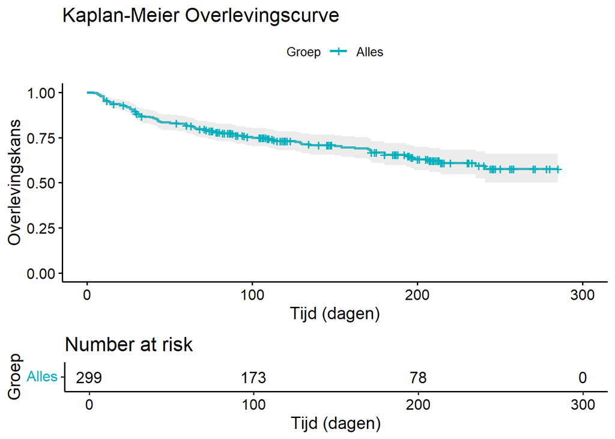

### Kaplan-Meier geslacht

[figure not shown]

### Kaplan-Meier leeftijd

```
## [1] 40
```

```
## [1] 95
```

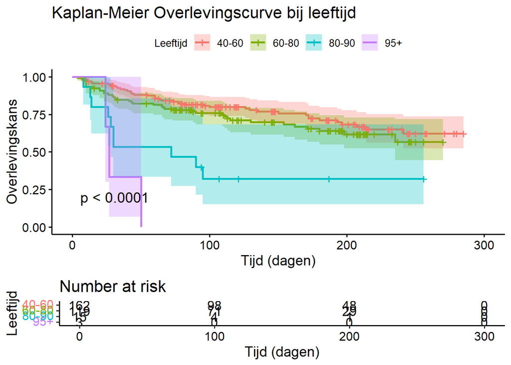

### Log-rank test op rokers

```
## Call:
## survdiff(formula = surv_obj ~ heart_data$smoking)
##
##                        N Observed Expected (O-E)^2/E (O-E)^2/V
## heart_data$smoking=0 203       66     65.8   0.00064   0.00204
## heart_data$smoking=1  96       30     30.2   0.00139   0.00204
##
##  Chisq= 0  on 1 degrees of freedom, p= 1
```